## A note on a prior for multinomial vector pairs

### Version 12/17/16, by MAN

*Set up:* In modeling single-cell RNASeq data, we imagine that cells fall into one of $K>1$ cell-type classes, and further that we have cells from two source conditions, giving $n_1$ and $n_2$ cells respectively. Let $z^1 = \{ z^1_k \}$ be multinomial counts recording the number of cells of each cell type in the first condition, and $z^2 = \{z^2_k \}$ be similar counts for the second condition. One task may be to infer something about possible equalities in the underlying probability vectors, which here I denote $\phi = \{ \phi_k \}$ and $\psi = \{ \psi_k \}$. I.e.
$$z^1 \sim \text{Multinomial}_K( n_1, \phi )$$
and
$$z^2 \sim \text{Multinomial}_K( n_2, \psi )$$

Here I describe a prior $p(\phi,\psi)$ that is conjugate to multinomial sampling but that also enables downstream gene-specific inferences about differential distribution when certain cell types do not differ in their expression distributions. To provide this functionality, we need to work with partitions of the cell-type classes, say $\pi = \{ b \}$ of $\{1, 2, \cdots, K\}$. Here $b$ indicates a block in the partition $\pi$, and of course different blocks do not overlap and they cover the whole set of classes: $\cup_{b \in \pi} b = \{1, 2, \cdots, K\}$. We recall there is a large number of such partitions $\pi$, say constituting the set $\Pi$ of cardinality Bell$(K)$. We’ll carry along an example involving $K=7$ cell types, and one three-block partition, shown in Figure 1, taken from the set of 877 possible partitions of $\{1, 2, \cdots, 7\}$.

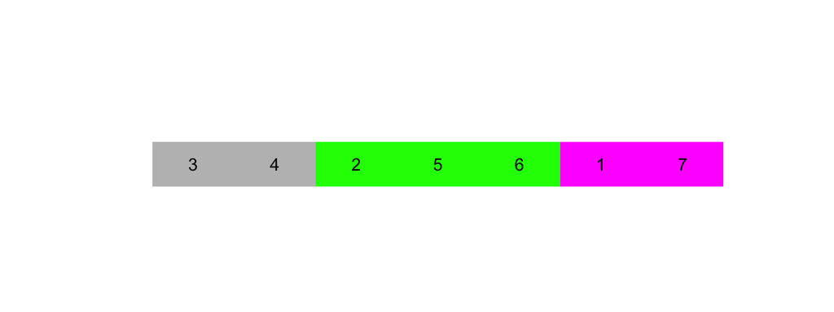

Example partition of $7$ cell types, $k$, into $3$ blocks, $b$

*Mixture prior:* For our purposes, the prior will have a *spike-slab* structure that mixes over distinct patterns of equality of $\pi$-associated accummulated probabilities:
$$p(\phi,\psi) = \sum_{\pi \in \Pi} p(c_\pi) \, p(\phi,\psi| c_\pi )$$
where
$$c_\pi = \{ (\phi,\psi): \Phi_b = \Psi_b \, \forall b \in \pi \}$$
where $\Phi_b = \sum_{k\in b} \phi_k$ and $\Psi_b = \sum_{k\in b} \psi_k$. Figure 2 shows one pair $(\phi, \psi)$ within $c_\pi$, where $\pi$ is from Figure 1.

Indeed, $c_\pi$ is precisely the structure needed to address differential distribution DD$_g$ at a given gene $g$ from expression data. Briefly, if the class probabilities satisfy $c_\pi$, and if the class-specific expression distributions are constant among classes $k$ within each $b \in \pi$, then even if there are differential proportions $\phi_k \neq \psi_k$ on such classes, this will not lead to differential distribution. More specifically, we say cell class specific means $\mu = \{ \mu_k \}$ satisfy expression pattern $d_\pi$ if
$$\mu_j = \mu_k \quad \forall j,k \in b, \quad \forall b \in \pi$$
EBSeq computed over the identified cell classes computes the posterior probability of $d_\pi$ given expression data, for all $\pi$ and at each gene. With ED$_g$ denoting *equivalent distribution*, which is the complement of DD$_g$,

*Conjecture:* At a given gene, equivalent distribution is
$$\text{ED}_g = \bigcup_{\pi \in \Pi}\left[ c_\pi \cap d_\pi \right].$$

The central point is that even allowing for cell-type probabilities to change between source conditions, there is no differential distribution at a given gene if the relevant cell types are not differentially expressed at that gene. Upon setting up a prior $p(\phi,\psi)$ that can mix over structures $c_\pi$, and by combining cell-type counts $z^1$ and $z^2$ with expression data $x_g$ at a gene, we may compute $P(\text{ED}_g|\text{data})$ at each gene:
$$P(\text{ED}_g|\text{data}) = \sum_{\pi \in \Pi} P(c_\pi|z^1, z^2) \,
P(d_\pi|x_g).$$

*Side issue:* Each structure $c_\pi$ is a closed subset of the product simplex holding all possible pairs of multinomial vectors $(\phi,\psi)$. As constructed, structures corresponding to different partitions are not disjoint, though we could refine the definition to encode disjointness. Consider the case where the partition $\pi$ has a refinement $\pi^*$, say (i.e. unions of blocks in $\pi^*$ lead to blocks in $\pi$). Then $c_{\pi^*} \subset c_\pi$ because of the aggregation constraint. Essentially the overlap represents a lower dimensional subset. Our approach is to define $p(\phi,\psi|c_\pi)$ in such a way that points in lower dimensional subsets receive zero probability mass in that mixture component, so that we don’t need to strictly enforce disjointness. It’s analogous to the spike-slab issue of a parameter $\theta$ that either equals 0 or does not; conditional on the latter case we might uses a Gaussian prior for $\theta$, which gives zero mass but positive density to the subset $\theta=0$. Another approach might be to force disjointness of $c_\pi$ (giving up closed sets) by removing from $c_\pi$ the $c_{\pi^*}$ corresponding to partition refinements of $\pi$. [needs to be worked out]

*Mixture components:* For notation, we use $\phi_b$ for the vector of values $\phi_k$ for $k \in b$, and similarly for $\psi_b$. Analogously, $\Phi_\pi$ and $\Psi_\pi$ are vectors of accumulated class probabilities $\phi_b$ and $\psi_b$ for all $b \in \pi$, respectively.

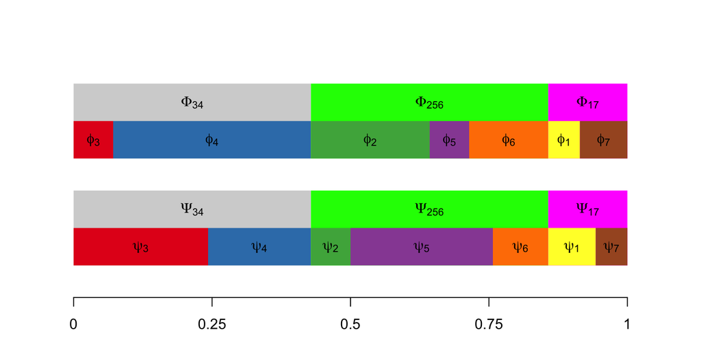

Multinomial probability vectors for two conditions arranged according to a fixed partition

Initially, the multitude of $p(c_\pi)$’s will be preset constants. To complete the prior specification $p(\phi,\psi)$, consider further scalers $\alpha_k>0$ for each class $k$ and $\beta_b>0$ for each potential block $b$. (Extending the notational convention, $\alpha_b$ is the vector of $\alpha_k$ for $k\in b$, and $\beta_\pi$ is the vector of $\beta_b$ for $b \in \pi$.) For any block $b$ consider conditional probabilities
$$\tilde{\phi}_b = \frac{\phi_b}{\Phi_b} \qquad \tilde{\psi}_b = \frac{\psi_b}{\Psi_b}$$
which indicate the conditional probability of each class $k$ given that the cell is of one of the types in $b$. Assume that conditional upon $(\phi,\psi) \in c_\pi$,
$$\Phi_\pi \sim \text{Dirichet}_{N(\pi)}[ \beta_\pi ]$$
where $N(\pi)$ is the number of blocks $b$ in $\pi$, and further that accumulated probabilities are the same between the two source conditions: $\Phi_\pi = \Psi_\pi$. Finally, assume that for each $b \in \pi$,
$$\tilde \phi_b, \tilde \psi_b \sim_{\text{i.i.d.}}
\text{Dirichlet}_{N(b)}[ \alpha_b ]$$
where $N(b)$ is the number of cell types in block $b$. In other words, if $c_\pi$ is the active structure, then accumulated probability vectors $\Phi_\pi$ and $\Psi_\pi$ are equal between the two source conditions, though the sub-block class-specific rates $\phi_k$ and $\psi_k$ may differ, as would (re-normalized) independent Dirichlet-distributed vectors. Taken together,
$$p(\phi,\psi|c_\pi) =
p( \Phi_\pi, \Psi_\pi | c_\pi ) \, \prod_{b \in \pi} \left[
p( \tilde \phi_b ) p( \tilde \psi_b ) \right]$$
with
$$p( \Phi_\pi, \Psi_\pi | c_\pi )
= \frac{\Gamma(\sum_{b\in \pi} \beta_b)}{
\prod_{b \in \pi} \Gamma( \beta_b )} \left[\prod_{b \in \pi} \Phi_b^{\beta_b-1} \right] \,
1\left[ \Phi_\pi = \Psi_\pi \right]$$
and
$$p( \tilde \phi_b ) =
\frac{ \Gamma( \sum_{k\in b} \alpha_k ) }{ \prod_{k\in b} \Gamma(\alpha_k) }
\prod_{k \in b} \tilde \phi_k^{\alpha_k -1 },
\qquad
p( \tilde \psi_b )
=
\frac{ \Gamma( \sum_{k\in b} \alpha_k ) }{ \prod_{k\in b} \Gamma(\alpha_k) }
\prod_{k \in b} \tilde \psi_k^{\alpha_k -1 }.$$

*Distributional consequences:* Using the Dirichlet-Multinomial conjugacy and the collapsing property of these distributions (cite), we get closed formulas for the predictive probability of cell-type counts $z^1$ and $z^2$. Fixing $\pi$, let $t^j_b = \sum_{k\in b} z^j_k$, for cell conditions $j=1,2$, record the total numbers of cells accumulated over all types in block $b$. And following our notation convention, $t^j_\pi$ is the vector of these counts over $b \in \pi$. From the prior and model structure
$$p(z^1,z^2|c_\pi) = p(z^1 | t^1_\pi)\, p(z^2| t^2_\pi )
\, p( t^1_\pi, t^2_\pi | c_\pi ).$$
Conditional independence of $z^1$ and $z^2$ given the block-level totals $t^1_\pi$ and $t^2_\pi$ on $c_\pi$ reflects the possible differential class proportion structure within blocks but between cell conditions. For either cellular group $j=1,2$, we find, after some simplification, the following Dirichlet-Multinomial masses:
$$p(z^j|t^j_\pi) = \prod_{b \in \pi} \left\{
\left[ \frac{ \Gamma(t^j_b +1 ) }{\prod_{k \in b} \Gamma( z^j_k + 1 ) }
\right]
\left[ \frac{\Gamma( \sum_{k \in b} \alpha_k )}{
\prod_{k\in b} \Gamma( \alpha_k ) } \right]
\left[ \frac{ \prod_{k \in b} \Gamma(\alpha_k + z^j_k) }{
\Gamma(t^j_b + \sum_{k\in b} \alpha_k ) )}\right]
\right\}$$
and
$$p(t^1_\pi,t^2_\pi| c_\pi) =
\left[ \frac{ \Gamma(n_1+1) \Gamma(n_2+1) }{ \prod_{b \in \pi} \Gamma(t^1_b+1)
\Gamma( t^2_b + 1 )} \right]
\left[ \frac{\Gamma( \sum_{b \in \pi} \beta_b )}{
\prod_{b \in \pi} \Gamma(\beta_b )} \right]
\left[ \frac{ \prod_{b \in \pi} \Gamma( \beta_b + t^1_b + t^2_b )}{
\Gamma( n_1 + n_2 + \sum_{b \in \pi} \beta_b )} \right].$$

Let’s look at some special cases to dissect this result.

**Check 1:** If $\pi$ has a single block equal to the entire set of cell types $\{1,2, \cdots, K\}$, then $t^j_b=n_j$ for both $j=1,2$, and the second formula reduces, correctly, to $p(t^1_\pi,t^2_\pi| c_\pi) = 1$. Further,
$$p(z^j|t^j_\pi) =
\left[ \frac{ \Gamma(n_j +1 ) }{ \Gamma( n_1 + \sum_{k=1}^K \alpha_k ) }
\right]
\left[ \frac{\Gamma( \sum_{k =1}^K \alpha_k )}{
\prod_{k=1}^K \Gamma( \alpha_k ) } \right]
\left[ \prod_{k=1}^K \frac{ \Gamma(\alpha_k + z^j_k)}{
\Gamma(z^j_k + 1 )}\right]$$
which is the well-known Dirichlet-multinomial predictive distribution for counts $z^j$ (cite). E.g, taking $\alpha_k=1$ for all types $k$ we get the uniform distribution
$$p(z^j|t^j_\pi) =
\frac{ \Gamma(n_j +1 ) \Gamma(K) }{ \Gamma( n_j + K ) }.$$

**Check 2:** At the opposite extreme, $\pi$ has one block $b$ for each class $k$. Then $t^j_b = z^j_k$, and $p(z^j|t^j_\pi) = 1$, and further, assuming $\beta_b = \alpha_k$,
$$p(t^1_\pi,t^2_\pi| c_\pi) =
\left[ \frac{ \Gamma(n_1+1) \Gamma(n_2+1) }{ \prod_{k=1}^K
\Gamma(z^1_k+1)
\Gamma( z^2_k + 1 )} \right]
\left[ \frac{\Gamma( \sum_{k=1}^K \alpha_k )}{
\prod_{k=1}^K \Gamma(\alpha_k )} \right]
\left[ \frac{ \prod_{k=1}^K \Gamma( \alpha_k + z^1_k + z^2_k )}{
\Gamma( n_1 + n_2 + \alpha_k )} \right].$$
*comment: cite a Bayes comparison of two multinomials*

Regardless of the partition, log scale probabilities are readily evaluated given hyper-parameters $\{ \alpha_k \}$ and $\{ \beta_b \}$ and for cell-type counts $z^1$ and $z^2$.

### Example

```
##      [,1] [,2] [,3] [,4] [,5] [,6] [,7]
## [1,]   38  183  110   28   77   27   37
## [2,]  128   93   46  117   46   46   24
```

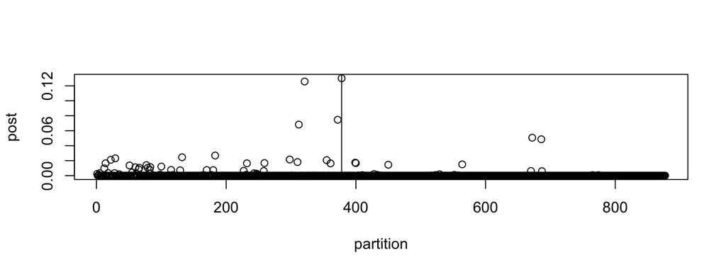

```
## [1] 2 2 1 1 1 3 3
```

```
##        1   2  3
## [1,] 215 221 64
## [2,] 209 221 70
```